# Part I - Ford GoBike System Data Analysis

## by (Yonathan Lesanework Ferede)

- Introduction
- Data Gathering
- Preliminary Data Exploration and Data Wrangling
- Data Cleaning
- Exploratory Data Visualization
- Univariate data Visualization
- Bivariate data Visualization
- Multivariate data Visualization
- Conclusions
- References

## Introduction

> The Ford GoBike System dataset includes information about individual rides made in a bike sharing system covering the greater San Francisco Bay area.

## Data Gathering

### Lets import all necessary libraries

```python
# import all packages and set plots to be embedded inline
import numpy as np
import pandas as pd
import matplotlib.pyplot as plt
import seaborn as sb
from math import radians, cos, sin, asin, sqrt

%matplotlib inline
```

### Lets load in our dataset.

```python
tripdata = pd.read_csv('201902-fordgobike-tripdata.csv')
```

## Preliminary Data Exploration and Data Wrangling

```python
#Lets explore our dataset by looking at the first 5 rows.
tripdata.head()
```

|  | duration_sec | start_time | end_time | start_station_id | start_station_name | start_station_latitude | start_station_longitude | end_station_id | end_station_name | end_station_latitude | end_station_longitude | bike_id | user_type | member_birth_year | member_gender | bike_share_for_all_trip |
| --- | --- | --- | --- | --- | --- | --- | --- | --- | --- | --- | --- | --- | --- | --- | --- | --- |
| 0 | 52185 | 2019-02-28 17:32:10.1450 | 2019-03-01 08:01:55.9750 | 21.0 | Montgomery St BART Station (Market St at 2nd St) | 37.789625 | -122.400811 | 13.0 | Commercial St at Montgomery St | 37.794231 | -122.402923 | 4902 | Customer | 1984.0 | Male | No |
| 1 | 42521 | 2019-02-28 18:53:21.7890 | 2019-03-01 06:42:03.0560 | 23.0 | The Embarcadero at Steuart St | 37.791464 | -122.391034 | 81.0 | Berry St at 4th St | 37.775880 | -122.393170 | 2535 | Customer | NaN | NaN | No |
| 2 | 61854 | 2019-02-28 12:13:13.2180 | 2019-03-01 05:24:08.1460 | 86.0 | Market St at Dolores St | 37.769305 | -122.426826 | 3.0 | Powell St BART Station (Market St at 4th St) | 37.786375 | -122.404904 | 5905 | Customer | 1972.0 | Male | No |
| 3 | 36490 | 2019-02-28 17:54:26.0100 | 2019-03-01 04:02:36.8420 | 375.0 | Grove St at Masonic Ave | 37.774836 | -122.446546 | 70.0 | Central Ave at Fell St | 37.773311 | -122.444293 | 6638 | Subscriber | 1989.0 | Other | No |
| 4 | 1585 | 2019-02-28 23:54:18.5490 | 2019-03-01 00:20:44.0740 | 7.0 | Frank H Ogawa Plaza | 37.804562 | -122.271738 | 222.0 | 10th Ave at E 15th St | 37.792714 | -122.248780 | 4898 | Subscriber | 1974.0 | Male | Yes |

```python
#Lets look at the last 5 rows.
tripdata.tail()
```

|  | duration_sec | start_time | end_time | start_station_id | start_station_name | start_station_latitude | start_station_longitude | end_station_id | end_station_name | end_station_latitude | end_station_longitude | bike_id | user_type | member_birth_year | member_gender | bike_share_for_all_trip |
| --- | --- | --- | --- | --- | --- | --- | --- | --- | --- | --- | --- | --- | --- | --- | --- | --- |
| 183407 | 480 | 2019-02-01 00:04:49.7240 | 2019-02-01 00:12:50.0340 | 27.0 | Beale St at Harrison St | 37.788059 | -122.391865 | 324.0 | Union Square (Powell St at Post St) | 37.788300 | -122.408531 | 4832 | Subscriber | 1996.0 | Male | No |
| 183408 | 313 | 2019-02-01 00:05:34.7440 | 2019-02-01 00:10:48.5020 | 21.0 | Montgomery St BART Station (Market St at 2nd St) | 37.789625 | -122.400811 | 66.0 | 3rd St at Townsend St | 37.778742 | -122.392741 | 4960 | Subscriber | 1984.0 | Male | No |
| 183409 | 141 | 2019-02-01 00:06:05.5490 | 2019-02-01 00:08:27.2200 | 278.0 | The Alameda at Bush St | 37.331932 | -121.904888 | 277.0 | Morrison Ave at Julian St | 37.333658 | -121.908586 | 3824 | Subscriber | 1990.0 | Male | Yes |
| 183410 | 139 | 2019-02-01 00:05:34.3600 | 2019-02-01 00:07:54.2870 | 220.0 | San Pablo Ave at MLK Jr Way | 37.811351 | -122.273422 | 216.0 | San Pablo Ave at 27th St | 37.817827 | -122.275698 | 5095 | Subscriber | 1988.0 | Male | No |
| 183411 | 271 | 2019-02-01 00:00:20.6360 | 2019-02-01 00:04:52.0580 | 24.0 | Spear St at Folsom St | 37.789677 | -122.390428 | 37.0 | 2nd St at Folsom St | 37.785000 | -122.395936 | 1057 | Subscriber | 1989.0 | Male | No |

```python
#Lets see the data types and other information about our dataset
tripdata.info()
```

```
<class 'pandas.core.frame.DataFrame'>
RangeIndex: 183412 entries, 0 to 183411
Data columns (total 16 columns):
 #   Column                   Non-Null Count   Dtype
---  ------                   --------------   -----
 0   duration_sec             183412 non-null  int64
 1   start_time               183412 non-null  object
 2   end_time                 183412 non-null  object
 3   start_station_id         183215 non-null  float64
 4   start_station_name       183215 non-null  object
 5   start_station_latitude   183412 non-null  float64
 6   start_station_longitude  183412 non-null  float64
 7   end_station_id           183215 non-null  float64
 8   end_station_name         183215 non-null  object
 9   end_station_latitude     183412 non-null  float64
 10  end_station_longitude    183412 non-null  float64
 11  bike_id                  183412 non-null  int64
 12  user_type                183412 non-null  object
 13  member_birth_year        175147 non-null  float64
 14  member_gender            175147 non-null  object
 15  bike_share_for_all_trip  183412 non-null  object
dtypes: float64(7), int64(2), object(7)
memory usage: 22.4+ MB
```

### Identifying the data types in our dataset

```python
tripdata.columns
```

```
Index(['duration_sec', 'start_time', 'end_time', 'start_station_id',
       'start_station_name', 'start_station_latitude',
       'start_station_longitude', 'end_station_id', 'end_station_name',
       'end_station_latitude', 'end_station_longitude', 'bike_id', 'user_type',
       'member_birth_year', 'member_gender', 'bike_share_for_all_trip'],
      dtype='object')
```

#### Contained in our dataset, we have:

> 7 Categorical (start_station_id, start_station_name, end_station_id, end_station_name, bike_id, user_type, member_gender) and

> 1 boolean (bike_share_for_all_trip) in our data set.

```python
# lets explore whether our dataset contains null values
tripdata.duplicated().sum()
```

```
0
```

```python
# lets see if our dataset contains null values
tripdata.isnull().sum()
```

```
duration_sec                  0
start_time                    0
end_time                      0
start_station_id            197
start_station_name          197
start_station_latitude        0
start_station_longitude       0
end_station_id              197
end_station_name            197
end_station_latitude          0
end_station_longitude         0
bike_id                       0
user_type                     0
member_birth_year          8265
member_gender              8265
bike_share_for_all_trip       0
dtype: int64
```

```python
# Lets explore how many unique values contained in our dataset
tripdata.nunique()
```

```
duration_sec                 4752
start_time                 183401
end_time                   183397
start_station_id              329
start_station_name            329
start_station_latitude        334
start_station_longitude       335
end_station_id                329
end_station_name              329
end_station_latitude          335
end_station_longitude         335
bike_id                      4646
user_type                       2
member_birth_year              75
member_gender                   3
bike_share_for_all_trip         2
dtype: int64
```

#### Quality Issues

- 'start_time', 'end_time' columns should be converted to datetime datatype.
- 'start_station_id', 'start_station_name', 'end_station_id', 'end_station_name', 'member_birth_year' & 'member_gender' columns contain null values

## Data Cleaning

Lets make a copy of our dataset so that we can start the cleaning process.

```python
tripdata_clean = tripdata.copy()
```

### Issue 1: 'start_time', 'end_time' columns are in the wrong data types

#### Define

Convert the data types of start_time and end_time column in to datetime.

#### Code

```python
tripdata_clean['start_time'] = pd.to_datetime(tripdata_clean['start_time'])
tripdata_clean['end_time'] = pd.to_datetime(tripdata_clean['end_time'])
```

#### Test

```python
print(tripdata_clean['start_time'].dtype)
print(tripdata_clean['end_time'].dtype)
```

```
datetime64[ns]
datetime64[ns]
```

### Issue 2: Null values in the dataset

#### Define

Since our dataset is very large and it is easier to remove rows containing null values in 'start_station_id', 'start_station_name', 'end_station_id', 'end_station_name', 'member_birth_year' & 'member_gender' columns.

#### Code

```python
tripdata_clean.shape
```

```
(183412, 16)
```

```python
tripdata_clean = tripdata_clean.dropna()
```

#### Test

```python
tripdata_clean.isnull().sum()
```

```
duration_sec               0
start_time                 0
end_time                   0
start_station_id           0
start_station_name         0
start_station_latitude     0
start_station_longitude    0
end_station_id             0
end_station_name           0
end_station_latitude       0
end_station_longitude      0
bike_id                    0
user_type                  0
member_birth_year          0
member_gender              0
bike_share_for_all_trip    0
dtype: int64
```

```python
tripdata_clean.shape
```

```
(174952, 16)
```

### Storing data

Save the cleaned dataset to a CSV file.

```python
tripdata_clean.to_csv('tripdata_clean.csv', encoding = 'utf-8', index = False)
```

## Exploratory Data Visualization

```python
tripdata = pd.read_csv('tripdata_clean.csv')
```

```python
tripdata.head()
```

|  | duration_sec | start_time | end_time | start_station_id | start_station_name | start_station_latitude | start_station_longitude | end_station_id | end_station_name | end_station_latitude | end_station_longitude | bike_id | user_type | member_birth_year | member_gender | bike_share_for_all_trip |
| --- | --- | --- | --- | --- | --- | --- | --- | --- | --- | --- | --- | --- | --- | --- | --- | --- |
| 0 | 52185 | 2019-02-28 17:32:10.145 | 2019-03-01 08:01:55.975 | 21.0 | Montgomery St BART Station (Market St at 2nd St) | 37.789625 | -122.400811 | 13.0 | Commercial St at Montgomery St | 37.794231 | -122.402923 | 4902 | Customer | 1984.0 | Male | No |
| 1 | 61854 | 2019-02-28 12:13:13.218 | 2019-03-01 05:24:08.146 | 86.0 | Market St at Dolores St | 37.769305 | -122.426826 | 3.0 | Powell St BART Station (Market St at 4th St) | 37.786375 | -122.404904 | 5905 | Customer | 1972.0 | Male | No |
| 2 | 36490 | 2019-02-28 17:54:26.010 | 2019-03-01 04:02:36.842 | 375.0 | Grove St at Masonic Ave | 37.774836 | -122.446546 | 70.0 | Central Ave at Fell St | 37.773311 | -122.444293 | 6638 | Subscriber | 1989.0 | Other | No |
| 3 | 1585 | 2019-02-28 23:54:18.549 | 2019-03-01 00:20:44.074 | 7.0 | Frank H Ogawa Plaza | 37.804562 | -122.271738 | 222.0 | 10th Ave at E 15th St | 37.792714 | -122.248780 | 4898 | Subscriber | 1974.0 | Male | Yes |
| 4 | 1793 | 2019-02-28 23:49:58.632 | 2019-03-01 00:19:51.760 | 93.0 | 4th St at Mission Bay Blvd S | 37.770407 | -122.391198 | 323.0 | Broadway at Kearny | 37.798014 | -122.405950 | 5200 | Subscriber | 1959.0 | Male | No |

```python
tripdata.describe()
```

|  | duration_sec | start_station_id | start_station_latitude | start_station_longitude | end_station_id | end_station_latitude | end_station_longitude | bike_id | member_birth_year |
| --- | --- | --- | --- | --- | --- | --- | --- | --- | --- |
| count | 174952.000000 | 174952.000000 | 174952.000000 | 174952.000000 | 174952.000000 | 174952.000000 | 174952.000000 | 174952.000000 | 174952.000000 |
| mean | 704.002744 | 139.002126 | 37.771220 | -122.351760 | 136.604486 | 37.771414 | -122.351335 | 4482.587555 | 1984.803135 |
| std | 1642.204905 | 111.648819 | 0.100391 | 0.117732 | 111.335635 | 0.100295 | 0.117294 | 1659.195937 | 10.118731 |
| min | 61.000000 | 3.000000 | 37.317298 | -122.453704 | 3.000000 | 37.317298 | -122.453704 | 11.000000 | 1878.000000 |
| 25% | 323.000000 | 47.000000 | 37.770407 | -122.411901 | 44.000000 | 37.770407 | -122.411647 | 3799.000000 | 1980.000000 |
| 50% | 510.000000 | 104.000000 | 37.780760 | -122.398279 | 101.000000 | 37.781010 | -122.397437 | 4960.000000 | 1987.000000 |
| 75% | 789.000000 | 239.000000 | 37.797320 | -122.283093 | 238.000000 | 37.797673 | -122.286533 | 5505.000000 | 1992.000000 |
| max | 84548.000000 | 398.000000 | 37.880222 | -121.874119 | 398.000000 | 37.880222 | -121.874119 | 6645.000000 | 2001.000000 |

### Observations to guide our Data Visualization

> We can the numerical data contained in our dataset to explore and answer some questions like the age of the users, for how long they use the bikeshare service etc.

> The Categorical data can be explored to answer some questions like from which stations users start the service, demographic distribution of the users etc.

## Univariate data Visualization

#### Lets try to answer some questions by using categorical and numerical data using univariate data visualizations.

> What does the demographic distribution of the users of the service look like?

> What are the stations where users pick up and drop off the bikes the most?

> What does the distribution of duration look like?

> Are most of the users customers or subscribers?

### 1.Lets see the Demographic distribution of the users by investigating the gender and age data.

#### A. Gender

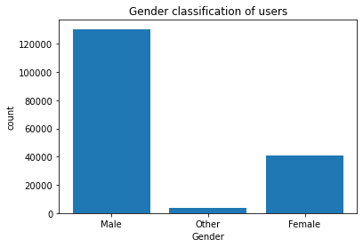

```python
# Gender distribution
# Return the Series having unique values
x = tripdata['member_gender'].unique()

# Return the Series having frequency count of each unique value
y = tripdata['member_gender'].value_counts(sort=False)

#plotting
plt.bar(x, y)

# Labeling the axes
def label(x,y,t):
    plt.xlabel(x)
    plt.ylabel(y)
    plt.title(t)
label('Gender','count','Gender classification of users')
```

```python
tripdata.member_gender.value_counts()
```

```
Male      130500
Female     40805
Other       3647
Name: member_gender, dtype: int64
```

```python
tripdata['member_gender'].value_counts(sort=False)
```

```
Male      130500
Other       3647
Female     40805
Name: member_gender, dtype: int64
```

### Observation 1

From the bar chart, we can clearly observe that Male customers are the most frequent users of the bike sharing service with more than 3x as much as Female customers.

#### B. Age

```python
#Lets check how many people born before 1940 are contained in our dataset
len(tripdata[tripdata.member_birth_year < 1940])
```

```
203
```

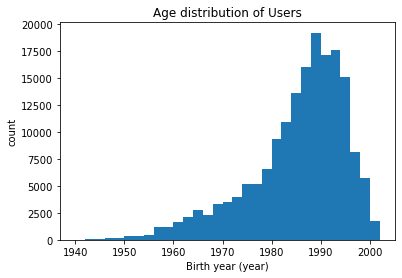

```python
#lets set the bins to remove outlier values (people born before 1940)
bins =np.arange(1940,tripdata.member_birth_year.max()+2,2)
plt.hist(data = tripdata, x = 'member_birth_year', bins = bins)

# Labels
label('Birth year (year)','count','Age distribution of Users')
```

### Observation 2

From the above histogram, we can observe that people born from the year 1988 - 1992 are the frequent users of the service.

### 2. What are the stations where users pick up and drop off the bikes the most?

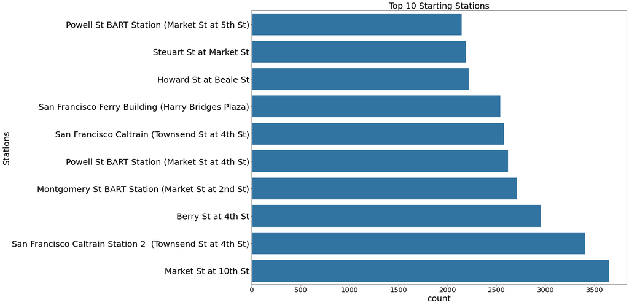

```python
# Starting Station distribution
# Return the Series having unique values

x = tripdata['start_station_name'].value_counts().sort_values(ascending = True)
x = x[-10:,]

#plotting
plt.figure(figsize = (20,15))
base_color = sb.color_palette()[0]
sb.barplot(x = x.values,y = x.index, color = base_color)
plt.xticks(fontsize=20);
plt.yticks(fontsize=25);
plt.title('Top 10 Starting Stations', fontsize = 25)
plt.xlabel('count', fontsize = 25)
plt.ylabel('Stations', fontsize = 25)
plt.show();
```

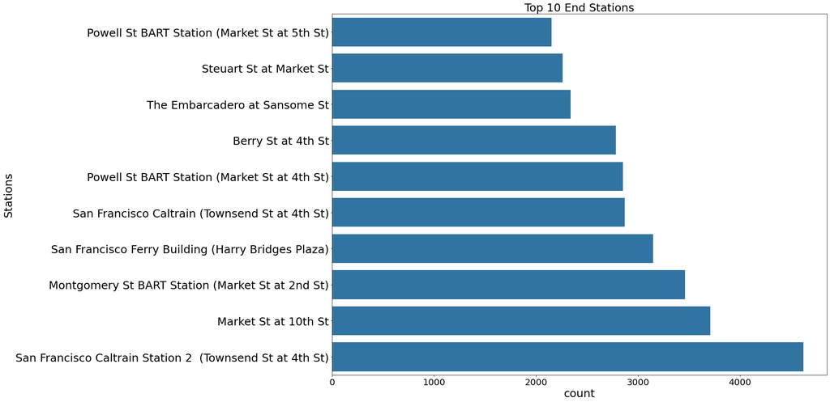

```python
# Stopping Station distribution
# Return the Series having unique values

a = tripdata['end_station_name'].value_counts().sort_values(ascending = True)
a = a[-10:,]

#plotting
plt.figure(figsize = (20,15))
base_color = sb.color_palette()[0]
sb.barplot(x = a.values,y = a.index, color = base_color)
plt.xticks(fontsize=20);
plt.yticks(fontsize=25);
plt.title('Top 10 End Stations', fontsize = 25)
plt.xlabel('count', fontsize = 25)
plt.ylabel('Stations', fontsize = 25)
plt.show();
```

### Observation 3

From the above visualizations, we can observe that Market St. at 10 St and San Francisco Caltrain Station 2 (Townsend ST at 4th st) are the most frequent starting and ending stations respectively.

### 3. What does the distribution of duration of usage of the bikes tell us?

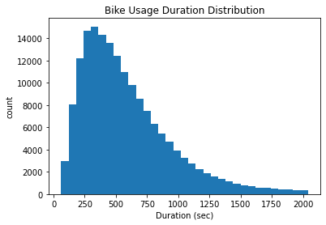

```python
# duration of rides
#lets set the bins to remove outlier values
bins =np.arange(60,2000+60,60)
plt.hist(data = tripdata, x = 'duration_sec', bins = bins)

#labels
label('Duration (sec)','count','Bike Usage Duration Distribution')
```

### Observation 4

Most riders use the bikes for shorter duration with the maximum count of people using the bikes for a duration of around 300 seconds.

### Are most of the users customers or subscribers?

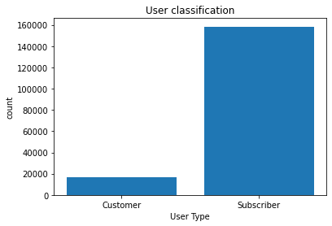

```python
# User type classification
# Return the Series having unique values
x = tripdata['user_type'].unique()

# Return the Series having frequency count of each unique value
y = tripdata['user_type'].value_counts(sort=False)

#plotting
plt.bar(x, y)

# Labeling the axes
label('User Type','count','User classification')
```

```python
tripdata.user_type.value_counts()
```

[output not shown]

### Observation 5

Our visualization shows that subscribed users of the ride share service heavily outnumber unsubscribed customers by more than 8x.

### Do most of the customers use bike share for all trips?

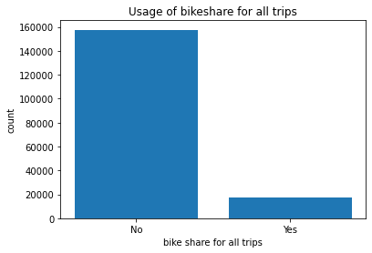

```python
# BIke share for all trips
# Return the Series having unique values
x = tripdata['bike_share_for_all_trip'].unique()

# Return the Series having frequency count of each unique value
y = tripdata['bike_share_for_all_trip'].value_counts(sort=False)

#plotting
plt.bar(x, y)

# Labeling the axes
label('bike share for all trips','count','Usage of bikeshare for all trips')
```

### Observation 6

According to our data, Most users don't use bikeshare for all trips.

## Bivariate Data Visualization

Lets try to answer some questions by using categorical and numerical data using Bivariate data visualizations.

> Do younger people ride the bikes for longer durations?

> Does gender influence whether users use the service without subscribing?

> What does the distribution of the Age of the customers look like across all genders?

```python
tripdata.head()
```

|  | duration_sec | start_time | end_time | start_station_id | start_station_name | start_station_latitude | start_station_longitude | end_station_id | end_station_name | end_station_latitude | end_station_longitude | bike_id | user_type | member_birth_year | member_gender | bike_share_for_all_trip |
| --- | --- | --- | --- | --- | --- | --- | --- | --- | --- | --- | --- | --- | --- | --- | --- | --- |
| 0 | 52185 | 2019-02-28 17:32:10.145 | 2019-03-01 08:01:55.975 | 21.0 | Montgomery St BART Station (Market St at 2nd St) | 37.789625 | -122.400811 | 13.0 | Commercial St at Montgomery St | 37.794231 | -122.402923 | 4902 | Customer | 1984.0 | Male | No |
| 1 | 61854 | 2019-02-28 12:13:13.218 | 2019-03-01 05:24:08.146 | 86.0 | Market St at Dolores St | 37.769305 | -122.426826 | 3.0 | Powell St BART Station (Market St at 4th St) | 37.786375 | -122.404904 | 5905 | Customer | 1972.0 | Male | No |
| 2 | 36490 | 2019-02-28 17:54:26.010 | 2019-03-01 04:02:36.842 | 375.0 | Grove St at Masonic Ave | 37.774836 | -122.446546 | 70.0 | Central Ave at Fell St | 37.773311 | -122.444293 | 6638 | Subscriber | 1989.0 | Other | No |
| 3 | 1585 | 2019-02-28 23:54:18.549 | 2019-03-01 00:20:44.074 | 7.0 | Frank H Ogawa Plaza | 37.804562 | -122.271738 | 222.0 | 10th Ave at E 15th St | 37.792714 | -122.248780 | 4898 | Subscriber | 1974.0 | Male | Yes |
| 4 | 1793 | 2019-02-28 23:49:58.632 | 2019-03-01 00:19:51.760 | 93.0 | 4th St at Mission Bay Blvd S | 37.770407 | -122.391198 | 323.0 | Broadway at Kearny | 37.798014 | -122.405950 | 5200 | Subscriber | 1959.0 | Male | No |

### Do younger people ride the bikes for longer durations?

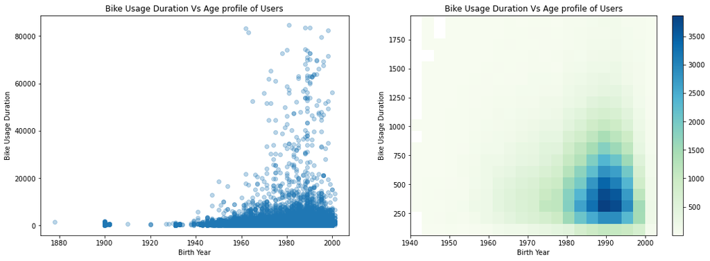

```python
# lets plot the duration vs birth year to answer this question
plt.figure(figsize = [18,6])
#plot on left
plt.subplot(1,2,1)
plt.scatter(data = tripdata, x = 'member_birth_year', y = 'duration_sec', alpha = 0.3)

#labels
label('Birth Year','Bike Usage Duration', 'Bike Usage Duration Vs Age profile of Users')

#plot on right
plt.subplot(1,2,2)
bins_x = np.arange(1940, tripdata.member_birth_year.max()+3, 3)
bins_y = np.arange(60, 2000, 100)
plt.hist2d(data = tripdata, x = 'member_birth_year',y= 'duration_sec', bins = [bins_x, bins_y],cmin = 0.5, cmap ='GnBu')
plt.colorbar()
label('Birth Year','Bike Usage Duration', 'Bike Usage Duration Vs Age profile of Users')
```

### Does gender influence whether users use the service without subscribing?

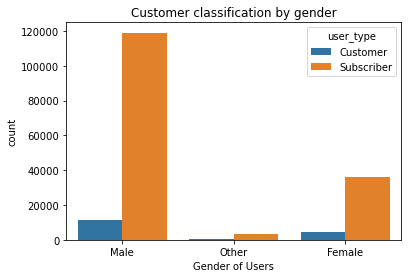

```python
sb.countplot(data = tripdata, x ='member_gender', hue = 'user_type');
plt.xticks(rotation = 0);
label('Gender of Users','count', 'Customer classification by gender')
```

### Observation 8

From our plot we can understand that Females customers are more likely to use the service without subscribing.

### What does the distribution of the Age of the customers look like across all genders?

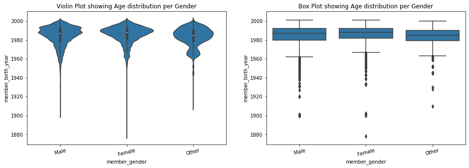

```python
#Convert the "member_Gender" column from a plain object type into an ordered categorical type
# Types of genders
Gender_classes = ['Male', 'Female', 'Other']

genders = pd.api.types.CategoricalDtype(ordered=True, categories=Gender_classes)

#convert the "member_gender" column from a plain object type into an ordered categorical type
tripdata['member_gender'] = tripdata['member_gender'].astype(genders);

# Step 4.  TWO PLOTS IN ONE FIGURE
plt.figure(figsize = [16, 5])
base_color = sb.color_palette()[0]

# LEFT plot: violin plot
plt.subplot(1, 2, 1)
#Let's return the axes object
ax1 = sb.violinplot(data=tripdata, x='member_gender', y='member_birth_year', color=base_color)
plt.xticks(rotation=15)
ax1.set(title="Violin Plot showing Age distribution per Gender");

# RIGHT plot: box plot
plt.subplot(1, 2, 2)
ax2 = sb.boxplot(data=tripdata, x='member_gender', y='member_birth_year', color=base_color)
plt.xticks(rotation=15);
plt.ylim(ax1.get_ylim())  # set y-axis limits to be same as left plot
ax2.set(title="Box Plot showing Age distribution per Gender");
```

### Observation 9

From our Violin and box plots, we can observe that the mean age has only slight difference between all genders. We can also observe a slightly more concentrated age profile for Female customers.

## Multivariate Visualization

Lets try to answer some questions by using categorical and numerical data using Multivariate data visualizations.

> What does the relationship between Age and duration look like?

> Is the relationship between Age and duration similar across all genders?

> What does the distribution of minimum travel distance of customers travel on their journey from station to station look like?

> What does a correlation matrix show us about the relationship of the variables?

> Show the positive correlation between duration and displacement across all genders.

### What does the relationship between Age and duration look like?

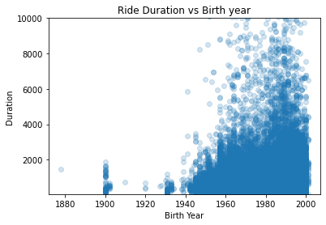

```python
# lets plot the duration vs birth year to answer this question
bins_x = np.arange(0.1,6,0.1)
bins_y = np.arange(60, 2000, 100)
plt.ylim([60,10000])
plt.scatter(data = tripdata, x = 'member_birth_year', y = 'duration_sec', alpha = 0.2);
label('Birth Year','Duration','Ride Duration vs Birth year')
```

### Is relationship between Age and duration similar across all genders?

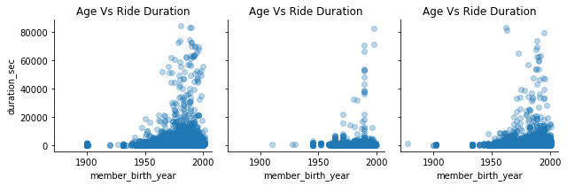

```python
g = sb.FacetGrid(data = tripdata, col = 'member_gender')
g.map(plt.scatter, 'member_birth_year', 'duration_sec', alpha = 0.3);
g.set(title ='Age Vs Ride Duration');
```

### Feature Engineering

We can use the start station and end station latitude and logitude values to compute length traveled in between two stations. Since the our formula will only tell us the shortest distance between the points, we will obtain the displacement rather than the distance traveled. Therefore, a displacement value of 0 would likely tell us that the customer made a round trip back to the station.

```python
def distance(lat1, lat2, lon1, lon2):

    # The math module contains a function named
    # radians which converts from degrees to radians.
    lon1 = radians(lon1)
    lon2 = radians(lon2)
    lat1 = radians(lat1)
    lat2 = radians(lat2)

    # Haversine formula
    dlon = lon2 - lon1
    dlat = lat2 - lat1
    a = sin(dlat / 2)**2 + cos(lat1) * cos(lat2) * sin(dlon / 2)**2

    c = 2 * asin(sqrt(a))

    # Radius of earth in kilometers. Use 3956 for miles
    r = 6371

    # calculate the result
    return(c * r)
```

```python
tripdata.index
```

```
RangeIndex(start=0, stop=174952, step=1)
```

```python
dist = []
for i in range(174952):
    dist.append(distance(tripdata.start_station_latitude[i],tripdata.end_station_latitude[i],tripdata.start_station_longitude[i],tripdata.end_station_longitude[i]))
tripdata['displacement'] = dist
```

Lets check whether our code has had the desired result or not.

If it did, we'll have the same number of data when we isolate where the displacement data = 0 and when we isolate where the trip start station id and end station id values are the same.

```python
tripdata.loc[tripdata.displacement == 0]
```

|  | duration_sec | start_time | end_time | start_station_id | start_station_name | start_station_latitude | start_station_longitude | end_station_id | end_station_name | end_station_latitude | end_station_longitude | bike_id | user_type | member_birth_year | member_gender | bike_share_for_all_trip | displacement |
| --- | --- | --- | --- | --- | --- | --- | --- | --- | --- | --- | --- | --- | --- | --- | --- | --- | --- |
| 17 | 874 | 2019-02-28 23:43:05.183 | 2019-02-28 23:57:39.796 | 180.0 | Telegraph Ave at 23rd St | 37.812678 | -122.268773 | 180.0 | Telegraph Ave at 23rd St | 37.812678 | -122.268773 | 5629 | Customer | 1978.0 | Male | No | 0.0 |
| 25 | 408 | 2019-02-28 23:48:08.282 | 2019-02-28 23:54:56.930 | 78.0 | Folsom St at 9th St | 37.773717 | -122.411647 | 78.0 | Folsom St at 9th St | 37.773717 | -122.411647 | 5410 | Subscriber | 1982.0 | Male | No | 0.0 |
| 31 | 471 | 2019-02-28 23:42:43.361 | 2019-02-28 23:50:34.446 | 133.0 | Valencia St at 22nd St | 37.755213 | -122.420975 | 133.0 | Valencia St at 22nd St | 37.755213 | -122.420975 | 5559 | Subscriber | 1992.0 | Male | No | 0.0 |
| 51 | 3478 | 2019-02-28 22:39:35.020 | 2019-02-28 23:37:33.342 | 11.0 | Davis St at Jackson St | 37.797280 | -122.398436 | 11.0 | Davis St at Jackson St | 37.797280 | -122.398436 | 1846 | Subscriber | 1995.0 | Male | No | 0.0 |
| 52 | 3140 | 2019-02-28 22:44:53.503 | 2019-02-28 23:37:14.090 | 11.0 | Davis St at Jackson St | 37.797280 | -122.398436 | 11.0 | Davis St at Jackson St | 37.797280 | -122.398436 | 3040 | Subscriber | 1983.0 | Female | No | 0.0 |
| ... | ... | ... | ... | ... | ... | ... | ... | ... | ... | ... | ... | ... | ... | ... | ... | ... | ... |
| 174863 | 1476 | 2019-02-01 02:45:04.744 | 2019-02-01 03:09:41.184 | 345.0 | Hubbell St at 16th St | 37.766483 | -122.398279 | 345.0 | Hubbell St at 16th St | 37.766483 | -122.398279 | 5224 | Subscriber | 1967.0 | Male | No | 0.0 |
| 174864 | 877 | 2019-02-01 02:53:15.995 | 2019-02-01 03:07:53.058 | 385.0 | Woolsey St at Sacramento St | 37.850578 | -122.278175 | 385.0 | Woolsey St at Sacramento St | 37.850578 | -122.278175 | 4913 | Subscriber | 1987.0 | Male | No | 0.0 |
| 174872 | 5713 | 2019-02-01 01:02:55.168 | 2019-02-01 02:38:09.002 | 31.0 | Raymond Kimbell Playground | 37.783813 | -122.434559 | 31.0 | Raymond Kimbell Playground | 37.783813 | -122.434559 | 5366 | Subscriber | 1972.0 | Male | No | 0.0 |
| 174895 | 874 | 2019-02-01 01:41:43.414 | 2019-02-01 01:56:17.552 | 253.0 | Haste St at College Ave | 37.866418 | -122.253799 | 253.0 | Haste St at College Ave | 37.866418 | -122.253799 | 3232 | Subscriber | 1995.0 | Male | Yes | 0.0 |
| 174921 | 943 | 2019-02-01 00:43:11.550 | 2019-02-01 00:58:55.217 | 31.0 | Raymond Kimbell Playground | 37.783813 | -122.434559 | 31.0 | Raymond Kimbell Playground | 37.783813 | -122.434559 | 5343 | Subscriber | 1972.0 | Male | No | 0.0 |

3458 rows × 17 columns

```python
tripdata.loc[tripdata.start_station_id == tripdata.end_station_id]
```

|  | duration_sec | start_time | end_time | start_station_id | start_station_name | start_station_latitude | start_station_longitude | end_station_id | end_station_name | end_station_latitude | end_station_longitude | bike_id | user_type | member_birth_year | member_gender | bike_share_for_all_trip | displacement |
| --- | --- | --- | --- | --- | --- | --- | --- | --- | --- | --- | --- | --- | --- | --- | --- | --- | --- |
| 17 | 874 | 2019-02-28 23:43:05.183 | 2019-02-28 23:57:39.796 | 180.0 | Telegraph Ave at 23rd St | 37.812678 | -122.268773 | 180.0 | Telegraph Ave at 23rd St | 37.812678 | -122.268773 | 5629 | Customer | 1978.0 | Male | No | 0.0 |
| 25 | 408 | 2019-02-28 23:48:08.282 | 2019-02-28 23:54:56.930 | 78.0 | Folsom St at 9th St | 37.773717 | -122.411647 | 78.0 | Folsom St at 9th St | 37.773717 | -122.411647 | 5410 | Subscriber | 1982.0 | Male | No | 0.0 |
| 31 | 471 | 2019-02-28 23:42:43.361 | 2019-02-28 23:50:34.446 | 133.0 | Valencia St at 22nd St | 37.755213 | -122.420975 | 133.0 | Valencia St at 22nd St | 37.755213 | -122.420975 | 5559 | Subscriber | 1992.0 | Male | No | 0.0 |
| 51 | 3478 | 2019-02-28 22:39:35.020 | 2019-02-28 23:37:33.342 | 11.0 | Davis St at Jackson St | 37.797280 | -122.398436 | 11.0 | Davis St at Jackson St | 37.797280 | -122.398436 | 1846 | Subscriber | 1995.0 | Male | No | 0.0 |
| 52 | 3140 | 2019-02-28 22:44:53.503 | 2019-02-28 23:37:14.090 | 11.0 | Davis St at Jackson St | 37.797280 | -122.398436 | 11.0 | Davis St at Jackson St | 37.797280 | -122.398436 | 3040 | Subscriber | 1983.0 | Female | No | 0.0 |
| ... | ... | ... | ... | ... | ... | ... | ... | ... | ... | ... | ... | ... | ... | ... | ... | ... | ... |
| 174863 | 1476 | 2019-02-01 02:45:04.744 | 2019-02-01 03:09:41.184 | 345.0 | Hubbell St at 16th St | 37.766483 | -122.398279 | 345.0 | Hubbell St at 16th St | 37.766483 | -122.398279 | 5224 | Subscriber | 1967.0 | Male | No | 0.0 |
| 174864 | 877 | 2019-02-01 02:53:15.995 | 2019-02-01 03:07:53.058 | 385.0 | Woolsey St at Sacramento St | 37.850578 | -122.278175 | 385.0 | Woolsey St at Sacramento St | 37.850578 | -122.278175 | 4913 | Subscriber | 1987.0 | Male | No | 0.0 |
| 174872 | 5713 | 2019-02-01 01:02:55.168 | 2019-02-01 02:38:09.002 | 31.0 | Raymond Kimbell Playground | 37.783813 | -122.434559 | 31.0 | Raymond Kimbell Playground | 37.783813 | -122.434559 | 5366 | Subscriber | 1972.0 | Male | No | 0.0 |
| 174895 | 874 | 2019-02-01 01:41:43.414 | 2019-02-01 01:56:17.552 | 253.0 | Haste St at College Ave | 37.866418 | -122.253799 | 253.0 | Haste St at College Ave | 37.866418 | -122.253799 | 3232 | Subscriber | 1995.0 | Male | Yes | 0.0 |
| 174921 | 943 | 2019-02-01 00:43:11.550 | 2019-02-01 00:58:55.217 | 31.0 | Raymond Kimbell Playground | 37.783813 | -122.434559 | 31.0 | Raymond Kimbell Playground | 37.783813 | -122.434559 | 5343 | Subscriber | 1972.0 | Male | No | 0.0 |

3458 rows × 17 columns

```python
tripdata.describe()
```

|  | duration_sec | start_station_id | start_station_latitude | start_station_longitude | end_station_id | end_station_latitude | end_station_longitude | bike_id | member_birth_year | displacement |
| --- | --- | --- | --- | --- | --- | --- | --- | --- | --- | --- |
| count | 174952.000000 | 174952.000000 | 174952.000000 | 174952.000000 | 174952.000000 | 174952.000000 | 174952.000000 | 174952.000000 | 174952.000000 | 174952.000000 |
| mean | 704.002744 | 139.002126 | 37.771220 | -122.351760 | 136.604486 | 37.771414 | -122.351335 | 4482.587555 | 1984.803135 | 1.690049 |
| std | 1642.204905 | 111.648819 | 0.100391 | 0.117732 | 111.335635 | 0.100295 | 0.117294 | 1659.195937 | 10.118731 | 1.096957 |
| min | 61.000000 | 3.000000 | 37.317298 | -122.453704 | 3.000000 | 37.317298 | -122.453704 | 11.000000 | 1878.000000 | 0.000000 |
| 25% | 323.000000 | 47.000000 | 37.770407 | -122.411901 | 44.000000 | 37.770407 | -122.411647 | 3799.000000 | 1980.000000 | 0.910443 |
| 50% | 510.000000 | 104.000000 | 37.780760 | -122.398279 | 101.000000 | 37.781010 | -122.397437 | 4960.000000 | 1987.000000 | 1.429829 |
| 75% | 789.000000 | 239.000000 | 37.797320 | -122.283093 | 238.000000 | 37.797673 | -122.286533 | 5505.000000 | 1992.000000 | 2.224010 |
| max | 84548.000000 | 398.000000 | 37.880222 | -121.874119 | 398.000000 | 37.880222 | -121.874119 | 6645.000000 | 2001.000000 | 69.469241 |

### What does the distribution of minimum travel distance of customers travel on their journey from station to station look like?

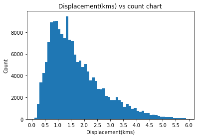

```python
#lets remove outlier values by setting bin values
bins = np.arange(0.1,6,0.1)
plt.hist(data = tripdata, x = 'displacement', bins = bins);
plt.xticks([0,0.5,1,1.5,2,2.5,3,3.5,4,4.5,5,5.5,6])
label('Displacement(kms)','Count','Displacement(kms) vs count chart')
```

### Observation 12

Most of the users used the bikesharing service travel a minimum distance of 0.5 to 1.5 kms.

### What does a correlation matrix show us about the relationship of the variables?

```python
#lets first drop latitude and longitude values as they are irrelevant in this analysis.

tripdata.drop(['start_station_latitude', 'start_station_longitude','end_station_latitude', 'end_station_longitude'], axis=1, inplace=True)
```

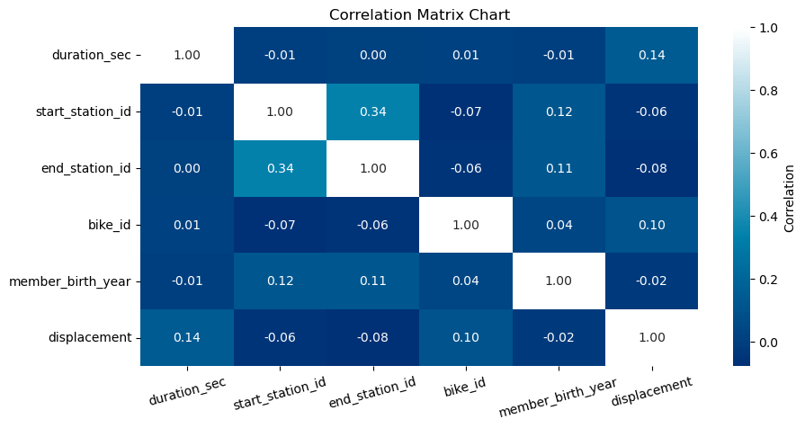

```python
# lets plot the matrics to observe the relatonships.
plt.figure(figsize = (10,5), dpi = 100)

sb.heatmap(tripdata.corr(), annot = True, fmt = '.2f', cmap = 'ocean', center = 0,cbar_kws={'label': 'Correlation'})

plt.title("Correlation Matrix Chart")
plt.xticks(rotation = 15)
plt.show()
```

### Observation 13

From our visualization, we can observe a slight positive correlation between the displacement and duration. We can also observe a correlation between Start station Id and end station Id meaning we might be able to where a customer will go from their start station.

### Show the positive correlation between duration and displacement across all genders.

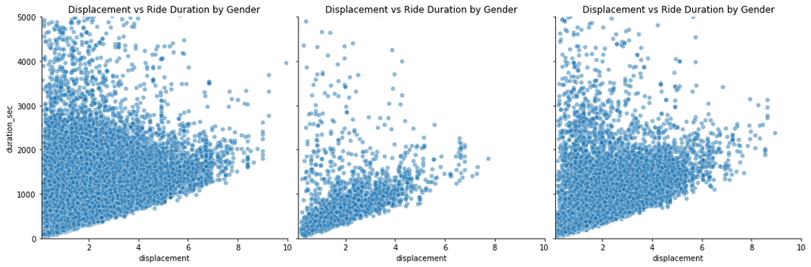

```python
g = sb.FacetGrid(data = tripdata, col = 'member_gender', size =5)
g.map(sb.scatterplot, 'displacement', 'duration_sec', alpha=0.5);
g.set(xlim=(0.1, 10))
g.set(ylim = (0,5000))
g.set(title = 'Displacement vs Ride Duration by Gender');
```

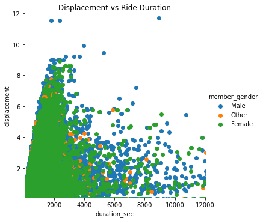

```python
# Visualising the combined graph after flipping the axis
g = sb.FacetGrid(data = tripdata, hue = 'member_gender', size =5)
g.map(plt.scatter, 'duration_sec','displacement')
g.set(xlim =(60,12000))
g.set(ylim = (0.1,12))
g.set(title = 'Displacement vs Ride Duration')
g.add_legend();
```

### Observation 14

Our scatter plot shows a slightly positive correlation between the duration and minimum distance traveled by the customers. The plot backs up the positive correlation shown in the correlation matrix plot.

## Conclusions

> Market St. at 10th St. and San Francisco Caltrain station 2 are the most frequent starting and stopping stations of the customers.

> Most users of the service are subscribers but don't use the bikeshare for all trips.

## References

> https://stackoverflow.com/questions/31594549/how-to-change-the-figure-size-of-a-seaborn-axes-or-figure-level-plot

> https://Kaggle.com